# A Quick Introduction to Web Development with Flask

## Why would you want to use Web Development!?

- Very accessible by EVERY internet capable device
- Support is (touch wood) easier to get than using a specialist tool
- No installation required, cross platform (even mobile!)
- Infinitely customizable
- Keep knowledge inhouse
- Pretty fun, breaks up analysis work

## What is Flask

Flask is a Python microframework, similar to Ruby's Sinatra

## Why Flask?

- Modern Web Application Framework
- A lot less complicated than Django ('Just Enough Framework')
- Very quick to get off the ground

## MVC 101

- User accesses controller (user interaction)
- Controller updates model (the data)
- Model updates view (presentation of data)
- User views View

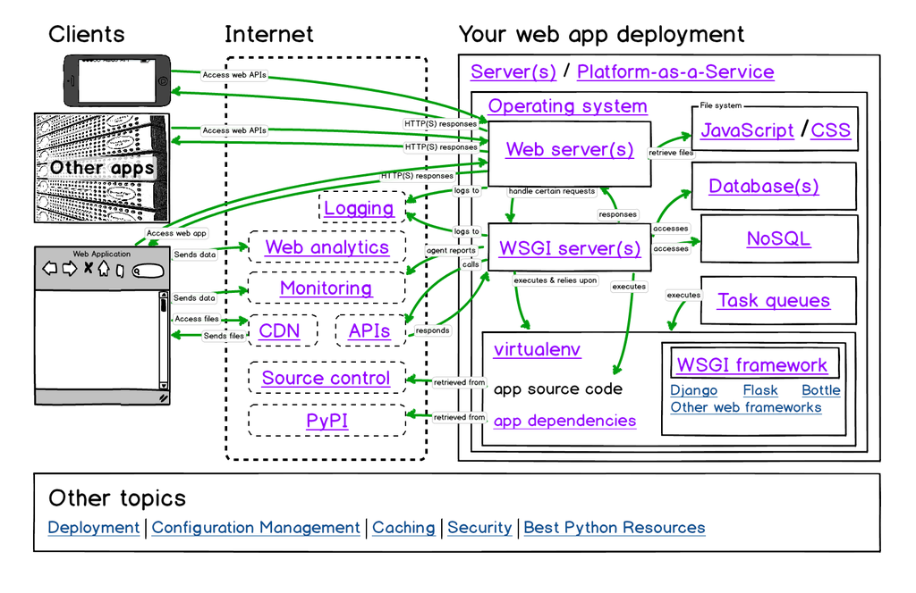

```python
from IPython.display import display, Image
Image(filename=r'./Assets/full-stack-python-map.png')
#Image from fullstackpython.com
```

## Back to the Titanic

Data Dictionary

pclass - Passenger Class (1 = 1st; 2 = 2nd; 3 = 3rd)

sex - Sex (0 Female, 1 Male)

age - Age (fractional before 1, xx.5 = estimated)

sibsp - Number of Siblings/Spouses Aboard

parch - Number of Parents/Children Aboard

fare - Passenger Fare

embarked - Port of Embarkation (0 = Cherbourg; 1 = Queenstown; 2 = Southampton)

```python
import requests
import json

url = 'http://localhost:5000/'
headers = {'Content-type': 'application/json', 'Accept': 'text/plain'}
passenger = {'Pclass': 3, 'Age': 27, 'SibSp': 0, 'Parch': 0, 'Fare' : 7.00, 'Embarked': 2, 'Gender': 1}
post_request = requests.post(url, data = json.dumps(passenger), headers=headers)
print(post_request.text)
```

```
You Live :)
```

## Want to learn more about Flask?

I suggest working through http://blog.miguelgrinberg.com/post/the-flask-mega-tutorial-part-i-hello-world on a unix based machine - this will give you a pretty good idea of how web applications are made.

Learn how to put this stuff on a real server with http://www.fullstackpython.com/